# Machine Learning: Chapter 5 - Part I

Missing Values Revisited

# Notations

Supervised Learning Model

$$Y = f(\bold{X}) + \varepsilon$$

Where

- $Y:=$ target feature
- $\bold{X}:=$ descriptive features
- $\varepsilon:=$ error term
- $f(\bold{X}):=$ unknown functional form

# Possible combinations

Given an observation $i$,

1. $Y_{i}$ is missing but $\bold{X}_{i}$ is intact or some of $\bold{X}_{i}$ are missing
2. $Y_{i}$ is not missing but some of $\bold{X}_{i}$ are missing
3. $Y_{i}$ is not missing but **all** $\bold{X}_{i}$ are missing
4. Both $Y_{i}$ and $\bold{X}_{i}$ are not missing
- Delete row $i$ for Case 3, as it is probably an error
- Case 4 is ideal *if* we have 90 to 95 % of such type in the data
- Let’s discuss and *attempt* to solve Case 1 and Case 2

# Case 1: Missing values in target feature $Y_{i}$

- You cannot train the model when $Y_{i}$ is missing
- Ask why $Y_{i}$ is missing
- $\implies$ Could it be due to transformation?
- Example: $\log{y}$ when $y=0$
- Keep it as part of test model but no evaluation
- Predict it! Isn’t it a data science job?

# Case 1: $Y_{i}$ is categorical

- Example: iris

```r
> data(iris)
> levels(iris$Species)
```

```
## [1] "setosa"     "versicolor" "virginica"
```

- What if `setosa` is taken out?
- Without prior knowledge, are there three or four or five species?
- Even with prior knowledge, you cannot train models without target values where `species = setosa`.
- Possible solution: Cluster analysis (Unsupervised Learning)
- Idea: hope that unsupervised learners would produce three respectives clusters for three species
- Suggested course: [COSC2670 Practical Data Science](http://www1.rmit.edu.au/courses/051637)

# Case 1: $Y_{i}$ is discrete

- Example: $Y:=$ count of wombats in Building 10
- $Y_{i}=0, 1, 2, 3, 4, 5, ...$
- Does $Y_{i}=0$ mean missing value or actual zero count?
- If there are excess zeroes, consider Zero-Inflated Poisson (ZIP) Model
- Two zero generating processes:
1. A binary distribution that generates structural zeros.
2. A Poisson distribution that generates counts which may be zero
- Suggested course: [MATH1298: Analysis of Categorical Data](http://www1.rmit.edu.au/courses/011998)

# Case 2: Missing values in $\bold{X}_{i}$

Types of missing values

1. Missing Completely At Random (MCAR)
2. Missing At Random (MAR)
3. Missing Not At Random (MNAR)
- Types 1 and 2 are okay
- Type 3 is problematic (no solution)

# Case 2: Example

# Case 2: First 10 observations of the example

| heartRate | CaloriesBurnt | MCAR | MAR | MNAR |
| --- | --- | --- | --- | --- |
| 69.39524 | 116.4480 | NA | 116.4480 | NA |
| 72.69823 | 121.2844 | 121.2844 | 121.2844 | 121.2844 |
| 90.58708 | 118.7665 | 118.7665 | 118.7665 | NA |
| 75.70508 | 118.2623 | 118.2623 | 118.2623 | NA |
| 76.29288 | 115.2419 | 115.2419 | 115.2419 | NA |
| 92.15065 | 119.7749 | 119.7749 | 119.7749 | NA |
| 79.60916 | 116.0755 | 116.0755 | 116.0755 | NA |
| 62.34939 | 111.6603 | 111.6603 | NA | NA |
| 68.13147 | 118.0989 | 118.0989 | 118.0989 | NA |
| 70.54338 | 124.5950 | 124.5950 | 124.5950 | 124.5950 |

# Case 2: MCAR

- Missingness does not depend on data
- $\implies$ Missingness of $X_{2}$ is not related to $X_{1}$ (other variable)
- $\implies$ Missingness of $X_{2}$ is not related to $X_{2}$ (itself)
- $P(\text{Missingness}|X_{2}) = P(\text{Missingness})$
- How to detect it? Conduct t-test to assess mean difference in $X_{1}$:

$$X_{1} | X_{2} \text{ is not missing vs } X_{1} | X_{2} \text{ is missing}$$

- Conclusion: it is likely MCAR if $H_0$ cannot be rejected.
- Problem: what if there are more than 2 variables?

# Case 2: MAR and MNAR

**MAR**

- Missingness depends only on observed data
- $\implies$ Missingness of $X_{2}$ is **related** to $X_{1}$ (other variable)

**MNAR**

- Missingness depends only on missing data
- $\implies$ Missingness of $X_{2}$ is **related** to $X_{2}$ (itself)

**Issues**

- In practice, it is difficult to distinguish MAR adn MNAR
- If you have prior knowledge about MNAR (i.e. you know why it is missing), mitigate it by asking for pre-processed data from data owner
- If you have no prior knowledge or you cannot mitigate MNAR, assume it is MAR

# Case 2: Solution?

- No complete solution; you can only mitigate it
- Recall: data processing cannot add new information
- MCAR: “Complete-Case” Analysis
- MAR: Imputation Methods
- MNAR: No solution. Risky solution is to assume it is MAR
- Practice, you can use methods who mitigate MAR on MCAR, but the reverse is not true

# Case 2: Complete-Case Analysis

# Case 2: Complete-Case Analysis Example

- Consider `heartRate` and `MCAR`

```r
> data <- read.csv('heartRateAndCaloriesBurnt.csv')
> df   <- data[, c('heartRate', 'MCAR')]
> sum(  complete.cases( df ) )
```

```
## [1] 93
```

- 93 complete cases out of 100 observations. This is not so bad
- Remove `NA` rows and calculate the number of rows

```r
> df  <- na.omit(df)
> nrow(df)
```

[output not shown]

- Try with `MNAR` and `MAR`.

# Case 2: Single imputation overview

| Imputation | Difficulty | Accuracy |
| --- | --- | --- |
| Unconditional Mean/Median/Mode | 1 | 1 |
| Unconditional Distribution | 2 | 2 |
| Conditional Mean | 3 | 3 |
| Conditional Distribution | 4 | 4 |

# Case 2: Single imputation method and issues (Part I)

**Unconditional Mean/Median/Mode**

- In R, use `mean(x, na.rm = FALSE)`

**Unconditional Distribution**

- Hot deck encoding: impute with a randomly choosen one non-missing value

# Case 2: Single imputation method and issues (Part II)

**Conditional Mean**

- Use linear regression to impute missing values
- Example in `R`
- Other regression methods also work
- R package: `missForest` (not recommended as we have `mlr`)

**Conditional Distribution**

- Add some random noises to linear regression

# Case 2: Single imputation visualisation

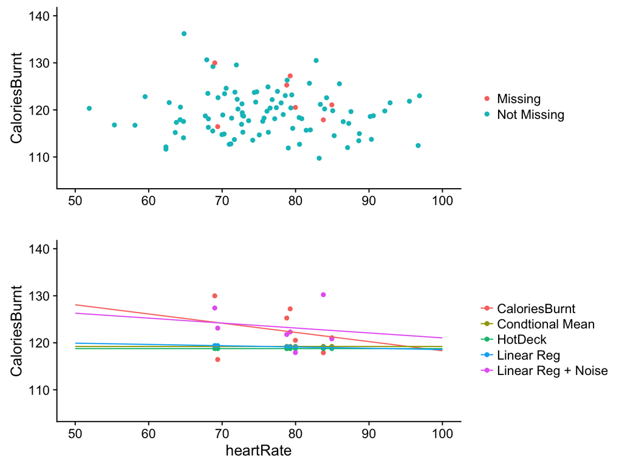

# Case 2: Imputation with `mlr`: An Example

- Data: `weightTypes`
- $n:=100$
- Descriptive Features:
1. `heartRate`
2. `CaloriesBurnt`
3. `numberOfMealsPerDay`
4. `gender`
5. `exerciseIntensity`
- Target feature = `weightType`

# Case 2: Unconditional mean imputation with `mlr`

- Impute by variable types

```r
library(mlr)
data2   <- read.csv('weightTypes.csv')
impute1 <- impute(data2, target = 'weightType',
                  classes = list(numeric = imputeMean(),
                                 factor  = imputeMode(),
                                 integer = imputeMedian())
                  )
```

- Get the imputed data set via `impute1$data`
- Get information via `impute1$desc`

# Case 2: Conditional mean with `mlr`

- Impute selected columns
- Let’s try decision tree on `exerciseIntensity`

```r
impute(data2, target = 'weightType',
       cols = list(
         CaloriesBurnt       = imputeNormal(),
         numberOfMealsPerDay = imputeMedian(),
         gender              = imputeMode(),
         exerciseIntensity   = imputeLearner("classif.rpart"))
)
```

# Case 2: Which learners offer imputations?

For regression,

- `listLearners("regr", properties = "missings")[c("class", "package")]`

For classification,

- `listLearners("classif", properties = "missings")[c("class", "package")]`

# Case 2: Sneak peek to multiple imputation

**Problems of Single Imputation**

- Too optimistic: Imputation model is an estimation, but not the true model
- $\implies$ imputed values have some uncertainty
- Solution: Multiple Imputation

**Multiple Imputation**

- Beyond scope of MATH2319
- Not recommended in the project
- R Package: `mice` (Multivariate Imputation by Chained Equations)
- It is based on Gibbs Sampler
- Recommended course: [MATH2269 Applied Bayesian Statistics](http://www1.rmit.edu.au/courses/050645)

# Summary

- Missing values in target features vs descriptive features
- Be pragmatic, use the right tools
- Types of missing values in descriptive features
- Key R functions to know: `mlr:impute` and `complete.cases`